# Practical Machine Learning Course Project 1 & 2

# 9. Build prediction model with Random Forest

```r
modelFitRf <- randomForest(classe~., data=myTraining, importance=TRUE, keep.forest=TRUE)
modelFitRf
```

```
##
## Call:
##  randomForest(formula = classe ~ ., data = myTraining, importance = TRUE,      keep.forest = TRUE)
##                Type of random forest: classification
##                      Number of trees: 500
## No. of variables tried at each split: 7
##
##         OOB estimate of  error rate: 0.17%
## Confusion matrix:
##      A    B    C    D    E  class.error
## A 3905    1    0    0    0 0.0002560164
## B    2 2655    1    0    0 0.0011286682
## C    0    5 2385    6    0 0.0045909850
## D    0    0    4 2246    2 0.0026642984
## E    0    0    0    2 2523 0.0007920792
```

```r
# Run the prediction based upon the modFit model created and the testing data
predictionRf<-predict(modelFitRf, myTesting)
confusionMatrix(predictionRf, myTesting$classe)
```

```
## Confusion Matrix and Statistics
##
##           Reference
## Prediction    A    B    C    D    E
##          A 1674    0    0    0    0
##          B    0 1139    1    0    0
##          C    0    0 1023    1    0
##          D    0    0    2  962    0
##          E    0    0    0    1 1082
##
## Overall Statistics
##
##                Accuracy : 0.9992
##                  95% CI : (0.998, 0.9997)
##     No Information Rate : 0.2845
##     P-Value [Acc > NIR] : < 2.2e-16
##
##                   Kappa : 0.9989
##  Mcnemar's Test P-Value : NA
##
## Statistics by Class:
##
##                      Class: A Class: B Class: C Class: D Class: E
## Sensitivity            1.0000   1.0000   0.9971   0.9979   1.0000
## Specificity            1.0000   0.9998   0.9998   0.9996   0.9998
## Pos Pred Value         1.0000   0.9991   0.9990   0.9979   0.9991
## Neg Pred Value         1.0000   1.0000   0.9994   0.9996   1.0000
## Prevalence             0.2845   0.1935   0.1743   0.1638   0.1839
## Detection Rate         0.2845   0.1935   0.1738   0.1635   0.1839
## Detection Prevalence   0.2845   0.1937   0.1740   0.1638   0.1840
## Balanced Accuracy      1.0000   0.9999   0.9984   0.9988   0.9999
```

```r
accuracy <- postResample(predictionRf, myTesting$classe)
model_accuracy <- accuracy[[1]]*100
model_accuracy
```

```
## [1] 99.91504
```

```r
out_of_sample_error <- 1 - as.numeric(confusionMatrix(myTesting$classe, predictionRf)$overall[1])
out_of_sample_error <- out_of_sample_error[[1]]*100
out_of_sample_error
```

```
## [1] 0.08496177
```

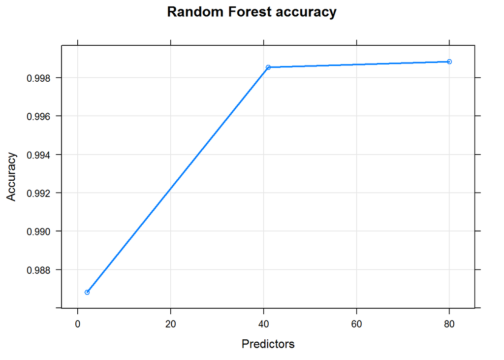

```r
# Plot the Random Forest model
plot(modelDTree, log = "y", lwd = 2, main = "Random Forest accuracy", xlab = "Predictors",
    ylab = "Accuracy")
```

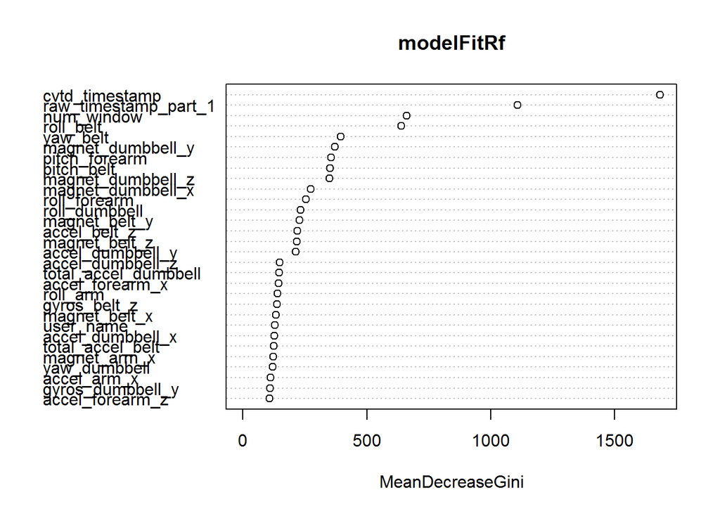

```r
# Run a varPlot to look at the importance of the variables
varImpPlot(modelFitRf, type=2)
```

As we can see, every time a split of a node is made on variable m the gini impurity criterion for the two descendent nodes is less than the parent node. Adding up the gini decreases for each individual variable over all trees in the forest gives a fast variable importance that is often very consistent with the permutation importance measure.

# 10. Cross Validation

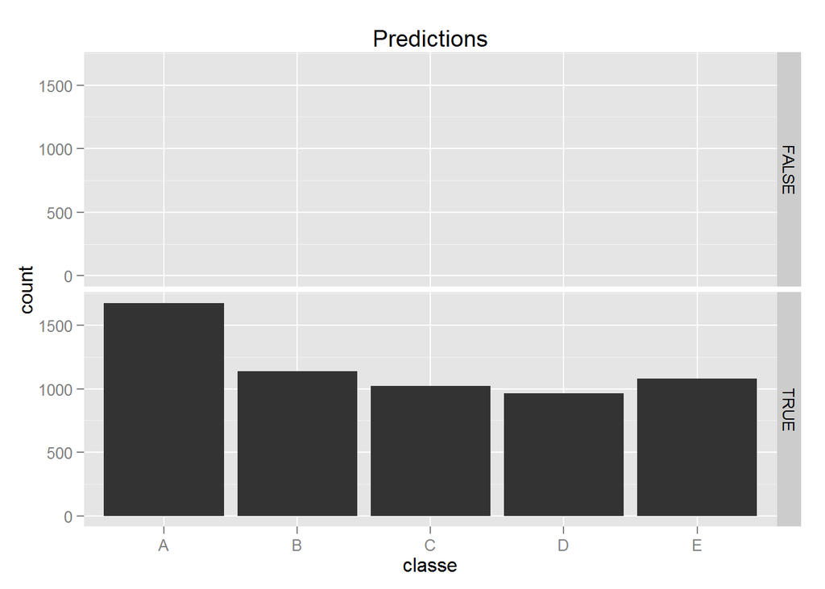

```r
myTesting$predRight <- predictionRf==myTesting$classe;
qplot(classe, data=myTesting, main="Predictions") + facet_grid(predRight ~ .)
```

The above prediction show that there is no overfitting.

# 11. Prediction Assignment Submission

For the submission phase of the assignment, run the new model and the prediction for the 20 new observations, and store the output in .txt files.

```r
final_prediction <- predict(modelFitRf, processedTestingData)
final_prediction
```

[1] B A B A A E D B A A B C B A E E A B B B  
Levels: A B C D E

```r
pml_write_files = function(x){
  n = length(x)
  for(i in 1:n){
    filename = paste0("problem_id_",i,".txt")
    write.table(x[i],file=filename,quote=FALSE,row.names=FALSE,col.names=FALSE)
  }
}
pml_write_files(final_prediction)
```